# An example workflow for building rangeModelMetadata objects

Jamie Kass, Cory Merow, Brian Maitner, Hannah Owens, Brian Enquist, Rob Guralnick

2020-02-13

```r
library(rangeModelMetadata)
library(rgbif)
library(raster)
library(dismo)
library(ENMeval)
library(dplyr)
library(sp)
library(spThin)
library(jsonlite)
```

# Building a range model

## Get data

```r
# search GBIF for occurrence data
bv <- rgbif::occ_search(scientificName ='Bradypus variegatus')
# restrict table to coordinates
occs <- dplyr::select(bv$data, decimalLongitude, decimalLatitude)
# remove duplicate values
occs <- occs[!duplicated(occs),]
# remove NAs
occs <- occs[complete.cases(occs),]
# make a stack of Worldclim v1.4 bioclim rasters
# Note 1: we are using the Worldclim version that comes with the current
# dismo distribution, which is the older v1.4 -- if you want to use v2.0 or
# a different dataset entirely, download it and place the file path here,
# instead of list.files(...)
# Note 2: as categorical variable "biome" has cells with NA where other bioclim
# variables have values, you may see some warnings when the predict functions
# are run
files <- list.files(path=paste(system.file(package='dismo'), '/ex',
                               sep=''), pattern='grd', full.names=TRUE)
envs <- raster::stack(files)
```

## Prepare data

```r
# thin points to remove spatial autocorrelation
occs.thinned <- spThin::thin.algorithm(data.frame(occs), thin.par=20, reps=1)
# make a spatial points object for the occurrences
occs.sp <- sp::SpatialPoints(occs.thinned[[1]])
# get the bounding box
bb <- sp::bbox(occs.sp)
# make extent object and buffer by 5 degrees
bb.buf <- raster::extent(bb[1]-5, bb[3]+5, bb[2]-5, bb[4]+5)
# crop environmental rasters by the extent to make the background extent
bg.ext <- raster::crop(envs, bb.buf)
# generate up to 10,000 random points within the background extent (we'll sample from the "biome" raster as it has more holes)
bg <- dismo::randomPoints(bg.ext[[9]], n=10000)
```

## Model Fitting

```r
# run ENMeval
e <- ENMeval::ENMevaluate(occs, bg.ext, bg, method='block', RMvalues=1:3, fc=c('L','LQ'), algorithm='maxnet')
```

```
## *** Running ENMevaluate using maxnet v.0.1.2 ***
```

```
## Doing evaluations using spatial blocks...
```

```
##
##  2 grid cells found with at least one NA value: these cells were excluded from raster predictions.
```

```
##
##  2 grid cells found with at least one NA value: these cells were excluded from raster predictions.
```

```
##
##  2 grid cells found with at least one NA value: these cells were excluded from raster predictions.
```

```
##
##  2 grid cells found with at least one NA value: these cells were excluded from raster predictions.
```

```
##
##  2 grid cells found with at least one NA value: these cells were excluded from raster predictions.
```

```
##
##  2 grid cells found with at least one NA value: these cells were excluded from raster predictions.
```

```
## ENMeval completed in 0 minutes 16.5 seconds.
```

## Model evaluation

```r
# find the index number of the model with the highest mean test AUC: this will be the optimal model
i <- which(e@results$avg.test.AUC  == max(e@results$avg.test.AUC ))
# extract the optimal model object
m <- e@models[[i]]
```

```r
e@results[i,]
```

```
##   settings features rm train.AUC avg.test.AUC var.test.AUC avg.diff.AUC
## 5      L_3        L  3 0.8716382    0.8084525    0.0513347    0.1066198
##   var.diff.AUC avg.test.orMTP var.test.orMTP avg.test.or10pct var.test.or10pct
## 5   0.03477422     0.05642507    0.004798646        0.2280987       0.06548386
##       AICc delta.AICc        w.AIC parameters
## 5 7174.443   139.4631 5.199706e-31          6
```

## Predictions

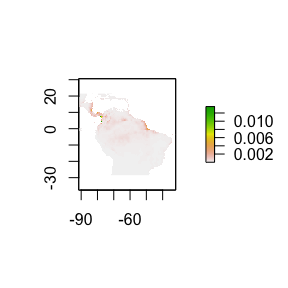

```r
# the prediction rasters produced by ENMeval are "raw" values,
# which correspond to the relative occurrence rate (ROR) per cell --
# see Merow et al. 2013 (Ecography)
p <- e@predictions[[i]]
plot(p)
```

## Transfer model

```r
# specify extent further south for model transfer (this region
# should have different climatic conditions than the region
# used to train the model). This could be useful if no observations
# are available in this region, but you're interested in determining
# if there are any potentially suitable areas there.
pt.bb <- raster::extent(-80,-40,-60,-30)
# crop environmental predictors by transfer extent
pt.ext <- raster::crop(envs, pt.bb)
pt <- ENMeval::maxnet.predictRaster(m, pt.ext, type = "exponential", clamp = TRUE)
```

```
##
##  1 grid cells found with at least one NA value: these cells were excluded from raster predictions.
```

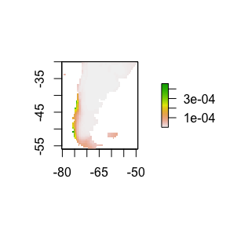

```r
plot(pt)
```

# Build an `rmm` object

Begin by choosing a few families of fields relevant for this analysis and making a template. This will generate all the recommended fields, although the only fields that you must fill in are in `base`.

```r
# generate an empty range model metadata template
rmm <- rmmTemplate(family=c('base','dataPrep','maxent','prediction',
                         'transferEnv1','binaryClassification'))
```

Note that to see a little bit less detail, it’s useful to use

```r
str(rmm, 1)
```

```
## List of 8
##  $ authorship    :List of 8
##  $ studyObjective:List of 4
##  $ data          :List of 5
##  $ dataPrep      :List of 4
##  $ model         :List of 9
##  $ prediction    :List of 6
##  $ assessment    :List of 5
##  $ code          :List of 8
##  - attr(*, "class")= chr [1:2] "list" "RMM"
```

```r
str(rmm, 2)
```

```
## List of 8
##  $ authorship    :List of 8
##   ..$ rmmName          : NULL
##   ..$ names            : NULL
##   ..$ license          : NULL
##   ..$ contact          : NULL
##   ..$ relatedReferences: NULL
##   ..$ authorNotes      : NULL
##   ..$ miscNotes        : NULL
##   ..$ doi              : NULL
##  $ studyObjective:List of 4
##   ..$ purpose  : NULL
##   ..$ rangeType: NULL
##   ..$ invasion : NULL
##   ..$ transfer : NULL
##  $ data          :List of 5
##   ..$ occurrence :List of 6
##   ..$ environment:List of 9
##   ..$ observation:List of 3
##   ..$ dataNotes  : NULL
##   ..$ transfer   :List of 1
##  $ dataPrep      :List of 4
##   ..$ dataPrepNotes: NULL
##   ..$ geographic   :List of 6
##   ..$ biological   :List of 5
##   ..$ environmental:List of 3
##  $ model         :List of 9
##   ..$ algorithms        : NULL
##   ..$ algorithmCitation : NULL
##   ..$ speciesCount      : NULL
##   ..$ selectionRules    : NULL
##   ..$ finalModelSettings: NULL
##   ..$ notes             : NULL
##   ..$ partition         :List of 3
##   ..$ references        : NULL
##   ..$ algorithm         :List of 1
##  $ prediction    :List of 6
##   ..$ binary       :List of 2
##   ..$ extrapolation: NULL
##   ..$ transfer     :List of 2
##   ..$ uncertainty  :List of 4
##   ..$ continuous   :List of 3
##   ..$ notes        : NULL
##  $ assessment    :List of 5
##   ..$ references         : NULL
##   ..$ notes              : NULL
##   ..$ trainingDataStats  :List of 12
##   ..$ testingDataStats   :List of 12
##   ..$ evaluationDataStats:List of 9
##  $ code          :List of 8
##   ..$ software        :List of 2
##   ..$ demoCodeLink    : NULL
##   ..$ vignetteCodeLink: NULL
##   ..$ fullCodeLink    : NULL
##   ..$ demoDataLink    : NULL
##   ..$ vignetteDataLink: NULL
##   ..$ fullDataLink    : NULL
##   ..$ codeNotes       : NULL
##  - attr(*, "class")= chr [1:2] "list" "RMM"
```

## Authorship

We start by filling in some key authorship information.

```r
  # in the form Author_Year_Taxa_Model_fw (where the last 2 characters are random)
rmm$authorship$rmmName <- 'MerowMaitnerOwensKassEnquistJetzGuralnick_2018_BradypusVariegatus_Maxent_b3'
  # names are distinct from citations (below) in case a citation does not exist
rmm$authorship$names <- 'Merow, Cory and Maitner, Brian and Owens, Hannah and Kass, Jamie and Enquist, Brian and Jetz, Walter and Guralnick, Rob'
rmm$authorship$contact <- 'cory.merow@gmail.com'
rmm$authorship$relatedReferences <- '@article{,
  title={RMMS: Species’ Range Model Metadata Standards },
  author={Merow, Cory and Maitner, Brian S. and Owens, Hannah L. and Kass,
          Jamie M. and Enquist, Brian and Jetz, Walter and Guralnick, Robert},
  journal={Global Ecology and Biogeography},
  year={2019}}'
rmm$authorship$license <- 'CC'
rmm$authorship$miscNotes <- 'Funding from NSF grant DBI-1661510 and DBI-1913673.'
```

## Study Objective

```r
rmm$studyObjective$purpose='transfer'
rmm$studyObjective$rangeType='potential'
rmm$studyObjective$transfer='detect unoccupied suitable habitat'
```

## Autofill when possible

```r
# occurrence data
rmm <- rmmAutofillspocc(rmm, bv$gbif)
# autofill info for environmental rasters used for model training and transfer
rmm <- rmmAutofillEnvironment(rmm, bg.ext, transfer=0)
rmm <- rmmAutofillEnvironment(rmm, pt.ext, transfer=1)
# autofill for ENMeval
rmm <- rmmAutofillENMeval(rmm, e,
                          selectionCriteria="highest mean test AUC",
                          optimalModelIndex=i)
# R packages used
rmm <- rmmAutofillPackageCitation(rmm=rmm,
                                  packages=
                                    c('rgbif','sp','raster','dismo','ENMeval'))
```

## Data

Now we need to fill in some fields manually.

```r
rmm$data$occurrence$sources <- lapply(rgbif::gbif_citation(bv),function(x) x$citation$citation)
rmm$data$occurrence$yearMin <- 1970
rmm$data$occurrence$yearMax <- 2000
```

Note that in the use of `gbif_citation` above, we use a journal formatted style for references, instead of bibtex, as used below. We chose this because the journal formatting is returned by `gbif_citation` and bibtex it not available. Rather than request that authors spend an inordinate amount of time manually reformatting perfectly good citations (which is error prone) we suggest simply using this default format.

```r
rmm$data$environment$yearMin <- 1960
rmm$data$environment$yearMin <- 1990
rmm$data$environment$sources <- '@article{hijmans2005,
  title={Very high resolution interpolated climate surfaces for global land areas},
  author={Hijmans, Robert J and Cameron, Susan E and Parra, Juan L and Jones, Peter G and Jarvis, Andy},
  journal={International Journal of Climatology: A Journal of the Royal Meteorological Society},
  volume={25},
  number={15},
  pages={1965--1978},
  year={2005},
  publisher={Wiley Online Library}
}'
rmm$data$dataNotes <- 'WorldClim v1.4 data accessed through dismo v1.1-4'
```

To fill in the min and max values of each data layer, it’s easiest to create a `data.frame` and convert that to JSON.

```r
mm <- data.frame(rbind(apply(values(envs),2,min,na.rm=T),
                    apply(values(envs),2,max,na.rm=T)))
rmm$data$environment$minVal <- toJSON(mm[1,])
(rmm$data$environment$maxVal <- toJSON(mm[2,])) # printed to show format
```

```
## [{"bio1":289,"bio12":7682,"bio16":2458,"bio17":1496,"bio5":422,"bio6":242,"bio7":461,"bio8":323,"biome":14}]
```

To fill in the extent of the layers, you can either do it manually or programatically. I do it programatically because I think it’s easier to make it JSON format.

```r
(ex <- extent(envs))
```

```
## class      : Extent
## xmin       : -125
## xmax       : -32
## ymin       : -56
## ymax       : 40
```

```r
# make an extent object a data.frame, because that's easy to use with toJSON
tmp <- as.data.frame(lapply(slotNames(ex), function(i) slot(ex, i) ))
names(tmp) <- slotNames(ex)
rmm$data$environment$extentSet <- toJSON(tmp)
```

Have I missed anything?

```r
rmmSuggest('$data') # note the use of quotes!
```

```
## $type
## [1] "field2"
##
## $suggestions
## [1] "data$occurrence"  "data$environment" "data$observation" "data$transfer"
## [5] "data$dataNotes"
```

Oh yeah, we haven’t dealt with the environment to which the model is transferred. In the modeling above we transferred to an adjacent region. So this follows analogous information provided for the fitting layers.

```r
rmm$data$transfer$environment1$yearMin <- 1970
rmm$data$transfer$environment1$yearMin <- 2000
rmm$data$transfer$environment1$resolution=paste0(res(pt.ext)[1],' degrees')
rmm$data$transfer$environment1$sources <- '@article{hijmans2005,
  title={Very high resolution interpolated climate surfaces for global land areas},
  author={Hijmans, Robert J and Cameron, Susan E and Parra, Juan L and Jones, Peter G and Jarvis, Andy},
  journal={International Journal of Climatology: A Journal of the Royal Meteorological Society},
  volume={25},
  number={15},
  pages={1965--1978},
  year={2005},
  publisher={Wiley Online Library}
}'

mm.pt <- data.frame(rbind(apply(values(pt.ext),2,min,na.rm=T),
                    apply(values(pt.ext),2,max,na.rm=T)))
rmm$data$transfer$environment1$minVal <- toJSON(mm.pt[1,])
(rmm$data$transfer$environment1$maxVal <- toJSON(mm.pt[2,])) # printed to show format
```

```
## [{"bio1":208,"bio12":6045,"bio16":1753,"bio17":1284,"bio5":345,"bio6":101,"bio7":336,"bio8":270,"biome":12}]
```

```r
(ex <- extent(pt.ext))
```

```
## class      : Extent
## xmin       : -80
## xmax       : -40
## ymin       : -56
## ymax       : -30
```

```r
# make an extent object a data.frame, because that's easy to use with toJSON
tmp <- as.data.frame(lapply(slotNames(ex), function(i) slot(ex, i) ))
names(tmp) <- slotNames(ex)
rmm$data$transfer$environment1$extentSet <- toJSON(tmp)
```

## Data Preparation (cleaning)

```r
# duplicated observations removed within the grid cells defined by the environmental layers
rmm$dataPrep$biological$duplicateRemoval$rule <- 'one observation per cell'
rmm$dataPrep$geographic$spatialThin$rule <- "20 km used as minimum distance between points"
```

```r
rmm$modelFit$maxent$notes <- 'ENMeval was used to compare models with L and LQ features, each using regularization multipliers of 1,2,3. The best model was selected based on test AUC evaluated with spatial cross validation.'
```

## Prediction

```r
# fill in remaining fields for model prediction in background extent
rmm$prediction$continuous$units <- "relative occurrence rate"
rmm$prediction$continuous$minVal <- cellStats(p, min)
rmm$prediction$continuous$maxVal <- cellStats(p, max)
# we chose to clamp our model predictions
rmm$prediction$extrapolation <- "clamping"
```

Analogous fields for transfer

```r
rmm$prediction$transfer$environment1$units <- "relative occurrence rate"
rmm$prediction$transfer$environment1$minVal <- cellStats(pt, min)
rmm$prediction$transfer$environment1$maxVal <- cellStats(pt, max)
rmm$prediction$extrapolation <- "clamping"
```

## Code

```r
rmm$code$software <- '@Manual{
  title = {R: A Language and Environment for Statistical Computing},
  author = {{R Core Team}},
  organization = {R Foundation for Statistical Computing},
  address = {Vienna, Austria},
  year = {2017},
  url = {https://www.R-project.org/},}'
rmm$code$vignetteCodeLink <- 'https://github.com/cmerow/rangeModelMetadata/blob/master/vignettes/rmm_workflowWithExampleRangeModel.Rmd'
```

## Check your `rmm` object

Let’s see how we’re doing so far by printing all the filled fields.

```r
#print just the non-NULL fields
rmmCleanNULLs(rmm)
```

```
## $authorship
## $authorship$rmmName
## [1] "MerowMaitnerOwensKassEnquistJetzGuralnick_2018_BradypusVariegatus_Maxent_b3"
##
## $authorship$names
## [1] "Merow, Cory and Maitner, Brian and Owens, Hannah and Kass, Jamie and Enquist, Brian and Jetz, Walter and Guralnick, Rob"
##
## $authorship$license
## [1] "CC"
##
## $authorship$contact
## [1] "cory.merow@gmail.com"
##
## $authorship$relatedReferences
## [1] "@article{, \n  title={RMMS: Species’ Range Model Metadata Standards },\n  author={Merow, Cory and Maitner, Brian S. and Owens, Hannah L. and Kass, \n          Jamie M. and Enquist, Brian and Jetz, Walter and Guralnick, Robert},\n  journal={Global Ecology and Biogeography},\n  year={2019}}"
##
## $authorship$miscNotes
## [1] "Funding from NSF grant DBI-1661510 and DBI-1913673."
##
##
## $studyObjective
## $studyObjective$purpose
## [1] "transfer"
##
## $studyObjective$rangeType
## [1] "potential"
##
## $studyObjective$transfer
## [1] "detect unoccupied suitable habitat"
##
##
## $data
## $data$occurrence
## $data$occurrence$dataType
## [1] "presence only"
##
## $data$occurrence$yearMin
## [1] 1970
##
## $data$occurrence$yearMax
```

[output cut: 183 more lines]

```
##
##
##
## $code
## $code$software
## [1] "@Manual{\n  title = {R: A Language and Environment for Statistical Computing},\n  author = {{R Core Team}},\n  organization = {R Foundation for Statistical Computing},\n  address = {Vienna, Austria},\n  year = {2017},\n  url = {https://www.R-project.org/},}"
##
## $code$vignetteCodeLink
## [1] "https://github.com/cmerow/rangeModelMetadata/blob/master/vignettes/rmm_workflowWithExampleRangeModel.Rmd"
##
##
## $modelFit
## $modelFit$maxent
## $modelFit$maxent$notes
## [1] "ENMeval was used to compare models with L and LQ features, each using regularization multipliers of 1,2,3. The best model was selected based on test AUC evaluated with spatial cross validation."
```

Check the final object by printing all the filled fields.

```r
#print just the non-NULL fields
rmmCleanNULLs(rmm)
```

```
## $authorship
## $authorship$rmmName
## [1] "MerowMaitnerOwensKassEnquistJetzGuralnick_2018_BradypusVariegatus_Maxent_b3"
##
## $authorship$names
## [1] "Merow, Cory and Maitner, Brian and Owens, Hannah and Kass, Jamie and Enquist, Brian and Jetz, Walter and Guralnick, Rob"
##
## $authorship$license
## [1] "CC"
##
## $authorship$contact
## [1] "cory.merow@gmail.com"
##
## $authorship$relatedReferences
## [1] "@article{, \n  title={RMMS: Species’ Range Model Metadata Standards },\n  author={Merow, Cory and Maitner, Brian S. and Owens, Hannah L. and Kass, \n          Jamie M. and Enquist, Brian and Jetz, Walter and Guralnick, Robert},\n  journal={Global Ecology and Biogeography},\n  year={2019}}"
##
## $authorship$miscNotes
## [1] "Funding from NSF grant DBI-1661510 and DBI-1913673."
##
##
## $studyObjective
## $studyObjective$purpose
## [1] "transfer"
##
## $studyObjective$rangeType
## [1] "potential"
##
## $studyObjective$transfer
## [1] "detect unoccupied suitable habitat"
##
##
## $data
## $data$occurrence
## $data$occurrence$dataType
## [1] "presence only"
##
## $data$occurrence$yearMin
## [1] 1970
##
## $data$occurrence$yearMax
```

[output cut: 183 more lines]

```
##
##
##
## $code
## $code$software
## [1] "@Manual{\n  title = {R: A Language and Environment for Statistical Computing},\n  author = {{R Core Team}},\n  organization = {R Foundation for Statistical Computing},\n  address = {Vienna, Austria},\n  year = {2017},\n  url = {https://www.R-project.org/},}"
##
## $code$vignetteCodeLink
## [1] "https://github.com/cmerow/rangeModelMetadata/blob/master/vignettes/rmm_workflowWithExampleRangeModel.Rmd"
##
##
## $modelFit
## $modelFit$maxent
## $modelFit$maxent$notes
## [1] "ENMeval was used to compare models with L and LQ features, each using regularization multipliers of 1,2,3. The best model was selected based on test AUC evaluated with spatial cross validation."
```

```r
# you can also use this function to omit the NULLs at the end of your workflow using, so if you're happy with the above...
rmm <- rmmCleanNULLs(rmm)
```

Now run all availables checks to be sure you’re ready to go.

```r
rmmCheckFinalize(rmm)
```

```
##
##
##
##  Element name ' $data$occurrence$backgroundSampleSize ' not found in data dictionary !
##  Did you mean: ' $data$occurrence$backgroundSampleSizeSet '? The following names are similar to suggested names, please verify:
## $data$occurrence$backgroundSampleSize
## Suggested alternatives include:
## $data$occurrence$backgroundSampleSizeSet
##  The following names are not similar to any suggested names, please verify that these are accurate:
## $data$occurrence$sources[[1]]
## $data$occurrence$sources[[2]]
## $data$occurrence$sources[[3]]
## $data$occurrence$sources[[4]]
## $data$occurrence$sources[[5]]
## $data$occurrence$sources[[6]]
## $data$occurrence$sources[[7]]
## $dataPrep$environmental
## $code$software
## $modelFit$maxent$notes
##
## ==========================================
## For the field rmm$authorship$license
##  The following entries appear accurate:
##
##  CC
##
## ==========================================
## For the field rmm$studyObjective$purpose
##  The following entries are not similar to any suggested values, please verify that these are accurate:
## transfer
##
## ==========================================
## For the field rmm$studyObjective$rangeType
##  The following entries are not similar to any suggested values, please verify that these are accurate:
## potential
##
## ==========================================
## For the field rmm$studyObjective$transfer
##  The following entries are not similar to any suggested values, please verify that these are accurate:
## detect unoccupied suitable habitat
```

[output cut: 48 more lines]

```
## For the field rmm$prediction$extrapolation
##  The following entries appear accurate:
##
##  clamping
##
## ==========================================
## For the field rmm$prediction$transfer$environment1$units
##  The following entries are similar to suggested values, please verify:
## relative occurrence rate
##
## Suggested alternatives include:
##  relative occurrence rate
##  ===================================
## ===================================
## All fields are populated.
```